# Analytics Edge: Unit 8 - An Introduction to Linear Optimization

Sulman Khan

October 26, 2018

## REVENUE MANAGEMENT

### Airline Regulation (1938-1978)

- The Civil Aeronautics Board (CAB) set fares, routes, and schedules for all interstate air transport
- Most major airlines favored this system due to guaranteed profits
- Led to inefficiency and higher costs
  - Applications for new routes and fares often delayed or dismissed

### Airline Deregulation (1978)

- The administration of President Jimmy Carter passed the Airline Deregulation Act in 1978
- The Act encouraged
  - **More competition**: 52 new airlines between 1980 and 2000
  - **New air routes**: saved passengers an estimated $10.3 billion each year in travel time
  - **Lower fares**: ticket prices are 40% lower today than they were in 1978
- This led to **more passengers**
  - The number of air passengers increased from 207.5 million in 197.4 to 721.1 million in 2010

### A competetitive Edge

- More competition led to heavy losses by air carriers
  - Need to lower fares while meeting operating costs
- 9 major carriers and more than 100 smaller airlines went bankrupt between 1978 and 2002
- How did airlines compete?

### Discount Fares

- On January 17, 1985 American Airlines (AA) launched its Ultimate Super Saver fares to compete with PeopleExpress
- Need to fill at least a minimum number of seats without selling every seat at discount prices
  - Sell enough seats to cover fixed operating costs
  - Sell remaining seats at higher rates to maximize revenues/profits

### How Many Seats to Sell on Discount

- Passengers have different valuations
  - Business people value flexibility (last-minute/refundable)
  - People seeking getaways value good deals (early birds)
- Sell too many discounted seats
  - Not enough seats for high-paying passengers
- Sell too few discounted seats
  - Empty seats at takeoff implying lost revenue
- How should AA allocates its seat among customers to maximize its revenue

### Simple Problem - JFK to LAX

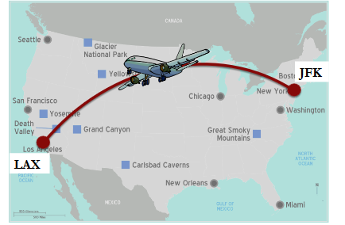

Route

[figure not shown]

Ticket Prices

[figure not shown]

166 Economy seats

#### Demand Forecasting

- Demand for different prices can be forecasted using analytics tools, looking at historical data and incorporating models of human behavior
  - Time series methods
  - Linear regression
- Forecasts could be erroneous
  - Need to assess sensitivity to forecast errors
- We’ll assume that demand has been forecasted

#### Myopic Solution

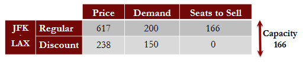

- How many discount seats to sell to maximize revenue
- This seems simple, but what if we had 100 different flights?

#### Single Route Example

- Problem: Find the optimal number of discounted seats and regular seats to sell to maximize revenue

#### Step 1: Decisions

- What are our decisions?
  - Number of regular seats to sell - R
  - Number of discount seats to sell - D

#### Step 2: Objective

- What is our objective?
  - Maximizing total airline revenue
  - Revenue from each type of seat is equal to the number of that type of seat sold times the seat price

$$max = 617R + 238D$$

#### Step 3: Constraints

- AA cannot sell more seats than the capacity
  - Total number of seats sold cannot exceed capacity

$$R \leq 100$$
+ Discount seats sold cannot exceed 150

$$D \leq 150$$

#### Step 4 : Non-Negativity

- AA cannot sell a negative number of seats

  $$R \geq 0 , D \geq 0$$

#### Problem Formulation

- Maximize
  - Total airline revenue

  $$617R + 238D$$
- Subject to
  - Seats sold cannot exceed capacity

  $$R + D \leq 166$$
  - Seats sold cannot exceed demand

  $$R \geq 0, D \geq 0$$

#### Visualizing the Problem

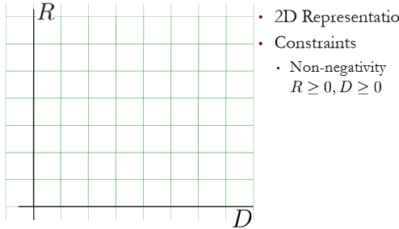

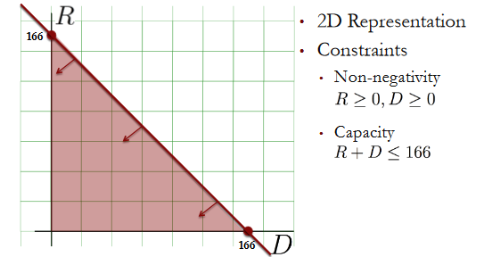

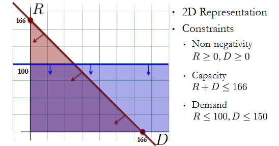

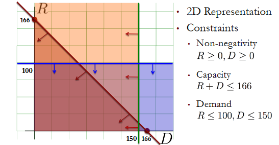

#### Feasible Space

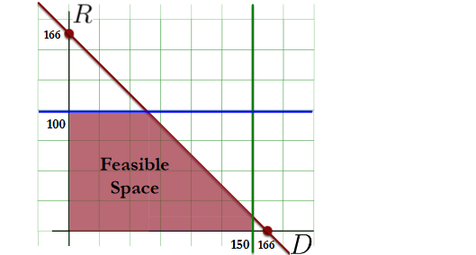

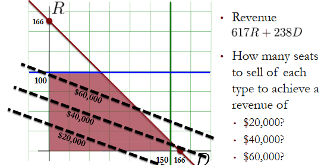

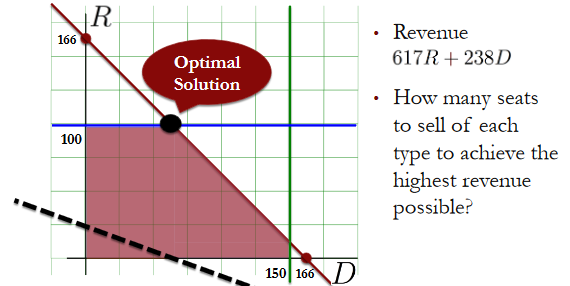

#### Marketing Decisions

- Management is trying to figure out whether it would be beneficial to invest in marketing its fares
- AA forecasts that its marketing effort is likely to attract one more unit of demand per $200 spent

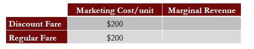

#### Marketing Discount Fares

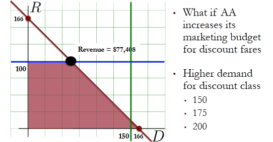

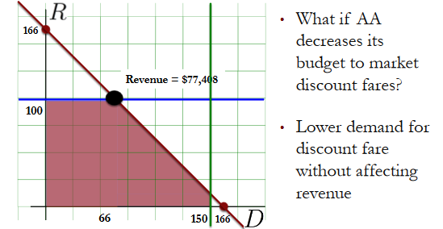

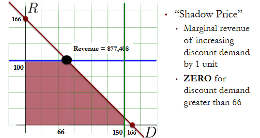

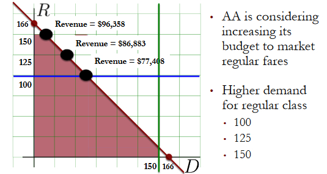

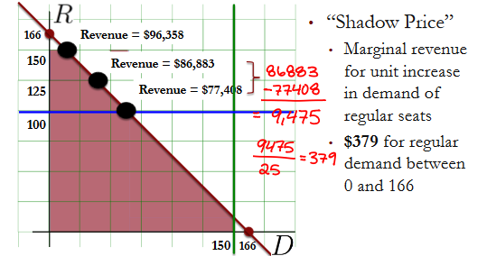

#### Marketing Decision

- Management is trying to figure out whether it would be beneficial to invest in marketing its fares
- AA forecasts that its marketing effort is likely to attract one more unit of demand per $200 spent

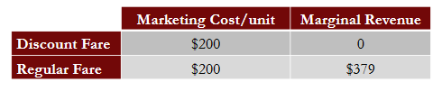

#### Capacity Allocation

- Management is trying to figure out whether it would be beneficial to allocate a bigger aircraft for the 6 hour JFK - LAX leg

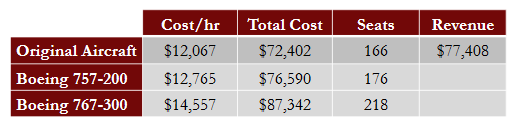

#### Aircraft Capacity

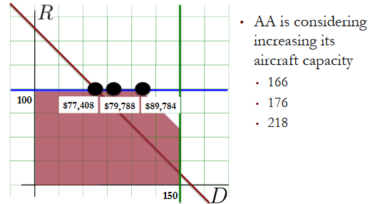

#### Capacity Allocation

- Management is trying to figure out whether it would be beneficial to allocate a bigger aircraft for the 6 hour JFK - LAX leg

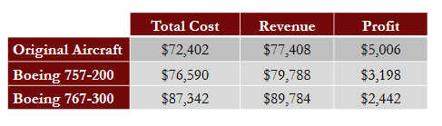

### Connecting Flights

#### Step 1: Decisions

- Number of regular seats to sell

$$R_{JFK-LAX} , R_{JFK-DFW} , R_{DFW-LAX}$$
* Number of discount seats to sell

$$D_{JFK-LAX} , D_{JFK-DFW} , D_{DFW-LAX}$$

#### Step 2: Objective

- Maximize total revenue

$$428R_{JFK-LAX} + 190D_{JFK-LAX} + 642R_{JFK-DFW} + 224D_{JFK-DFW} + 512R_{DFW-LAX} + 190D_{DFW-LAX}$$

#### Step 3: Constraints

- AA cannot sell more seats than the aircraft capacity
  - First leg - JFK-DFW

  $$R_{JFK-LAX} + D_{JFK-LAX} + R_{JFK-DFW} + D_{JFK-DFW} \leq 166$$
  - Second leg - DFW-LAX

  $$R_{JFK-LAX} + D_{JFK-LAX} + R_{DFW-LAX} + D_{DFW-LAX} \leq 166$$
- AA cannot sell more seats than the demand

$$R_{JFK-LAX} \leq 80 , D_{JFK-LAX} \leq 120$$
$$R_{JFK-DFW} \leq 75 , D_{JFK-DFW} \leq 100$$
$$R_{DFW-LAX} \leq 60 , D_{DFW-LAX} \leq 110$$

#### Step 4: Non-Negativity

- AA cannot sell a negative number of seats

$$R_{JFK-LAX} \geq 0 , D_{JFK-LAX} \geq 0$$
$$R_{JFK-DFW} \geq 0 , D_{JFK-DFW} \geq 0$$
$$R_{DFW-LAX} \geq 0 , D_{DFW-LAX} \geq 0$$

### The Competitive Strategy of AA

- Selling the right seats to the right customers at the right prices

“**Revenue management** is the single most important technical development in transportation management since we entered the era of airline deregulation.” - Robert Crandall, former CEO of AA (~1985)

“We estimate that revenue management has generated **$1.4 billion in incremental revenue** in the last three years.” - Robert Crandall, former CEO of AA (~1985)

### The Edge of Revenue Management

- Sabre Holdings
  - Built revenue management system for AA
  - As of November 2012, ranked 133 among America’s largest private companies with $3.15 billion in sales
  - 400 airlines, 90,000 hotels, 30 car-rental companies
- Today, companies prosper from revenue management
  - Delta airlines increased annual revenue by $300 million
  - Marriott hotels increased annual revenue by $100 million